### [Math](http://www.calvin.edu/academic/math) 252 [Discrete Mathematics for Computer Science](http://rpruim.github.io/m252/S20/) Spring 2020

[[Webwork](https://mathwebwork.cs.calvin.edu/webwork2/Math252-S20-Pruim)] [[MS Team](https://teams.microsoft.com/l/team/19%3a076ad0b56a6146509163f69ae34a2740%40thread.tacv2/conversations?groupId=fd1cdf22-72c3-4d88-b309-1a0939c70ec0&tenantId=756349b9-0610-4b01-917b-2a4ac10df947)] [From Class] [Calendar] [Test Info] [Homework]

## Test Information

Information about tests will be posted here shortly before each test.

### Black out date requests

You can request that we not have a test on a particular day by filling out [this form](https://docs.google.com/forms/d/e/1FAIpQLSdVNA5aqsRvNoyUjPRU_fxG1MIj4LGfIrzOFs37PjQjzuXPDw/viewform?usp=sf_link) I can’t promise to meet all requests, but I’ll do what I can to work with the data.

### Test 1

**Date:** Friday, March 6

**Material Covered**: Graphs (Rosen chapter 10.1-10.5, 10.7) and Counting (Rosen 6.1-6.5)

#### Topics

**Graphs:** modeling with graphs (what do edges and vertices represent?); types of graphs(directed, undirected, self-loops, etc., etc.); graph terminology (examples: vertex, edge, adjacent, degree, bipartite, path, connected, connected component); graph representations (adjacency matrix, incidence matrix, edge list, adjacency list); graph isomorphism; graph invariants; Euler paths and circuits; Hamilton paths and circuits; planar graphs; Euler’s formula; Kuratowski’s Theorem; proving a graph is not planar *without* using Kuratowski’s Theorem (like we did for $K_{5}$ and $K_{3,3,}$.

**Counting:** bijection principle (no double counting, no skipping); multiplication principle; addition principle; subtraction principle; inclusion-exclusion; division principle; pigeonhole principle; permutations and combinations; binomial coefficients; the “donut problems”.

### Test 2

**Date:** Friday, May 1

**Material Covered**:

- Counting and Probability (Rosen 6 and 7)
- Languages, Grammars, and Automata (Rosen 13.1 – 13.4)

#### Logistics

We will be using RPNow for Test 2. I’ve created a short practice test for you so you can make sure you understand in advance how the test logistics will work. **I highly recommend that you do this before Friday.**

Allow yourself 75 minutes to take the test.

- 10 minutes for setting up, pre-check, submitting, etc.
- 65 minutes for the exam itself.

Unless you have made other arrangements with me, you must begin the exam between 11 am and 12:40 pm. Once you begin the exam in Moodle, you will have 65 minutes to complete it.

##### What is allowed during the exam?

- You may use a **calculator**, but not your phone or any other devices.
- You may not use any additional software on your computer other than Moodle via the secure browser.
  - Note: RPnow will require you to close some applicaitons to even run, but all application use will be logged while you take the test.
- You may have **pencils, pens, and erasers**, and some **blank paper** to write on.
  - You will show that this paper is blank during your room scan
  - You will submit your paper via gradescope when you are finished.
- You may not have other notes or books, consult other people or the internet.

##### How does RPnow work?

Here are some **detailed instructions for using RPNow** (for either the practice or the actual test).

#### Topics

**Counting:** Bijection principle (no double counting, no skipping); multiplication principle; addition principle; division principle; inclusion-exclusion; permutations and combinations; binomial coefficients; inclusion-exclusion.

**Probability:** Definition of finite probability and applications involving counting problems; empirical vs theoretical probability; 3 probability axioms; complement rule; equally likely rule; union rule; conditional probability; indepedence; Bayes probability (e.g., false positives and false negatives); probability trees; random variables; expected value of a random variable; linearity of expected value; Binomial distributions.

**Grammars:** Components of a grammar (terminals, nonterminals, start symbol, production rules, etc.), derivations, language generated by a grammar, types of grammars (regular, context sensitive, context free).

**Automata:** Components of an automaton (input alphabet, states, start state, final states, transition funciton), DFA, NFA, language recognized by an automaton, building up a complex automaton from component automata; .

**Regular expressions:** Notation, three base cases and three operations, language represented by a regular expression.

**Regular languages:** Equivalence of regular expressions, regular grammars, DFAs, and NFAs. You should know how to do the following conversions: DFA $\to$ NFA; NFA $\to$ DFA; regular expression $\to$ NFA; regular grammar $\to$ NFA; NFA $\to$ regular grammar; DFA/NFA $\to$ regular expression.

Basically, you should know all the arrows on this diagram:

$$\Large
\begin{array}{ccccccc}
\mathrm{DFA} & \longleftrightarrow & \mathrm{NFA} & \longrightarrow & \lambda\mathrm{-NFA} & \longrightarrow & \mathrm{GNFA} \\
&& \downarrow \uparrow & \nwarrow & & \swarrow \\
& & \mathrm{regular}& & \mathrm{regular} \\
& & \mathrm{grammar}& & \mathrm{expression}
\end{array}$$

Notes:

- Counting topics will largely arise in the context of probability calculations.
- Some of you may have seen extended regular expressions that include additional operators like $+$. These are **not** included in our definition of regular expression. (We will say something more about these later.)

### Final Exam

**Date/Time:** 1:30 pm on Wednesday, May 20 or 9 am on Thursday, May 21.

- Use this [sign up sheet](https://docs.google.com/forms/d/e/1FAIpQLSdzTLw97yIrneWvpSAj0t-fa2SGHeqjca7cuAAThCR0XGS13w/viewform?usp=sf_link) to tell me which time you plan to take the exam.

#### Logistics

##### Respondus

We will be using Respondus for the Final Exam. This is similar to RPnow, but appears to be a simpler to use. (You will just navigate to the test inside Moodle since the integration with Moodle is tighter.)

- Respondus instructions

I’ll be creating a **practice quiz** like I did for test 2 so that you can test out the entire workflow prior to the final exam. I’ll let you know when that is ready to go. **Please do this and let me know if you have any problems on your end.**

You will have up to 3 hours to take the test, but it will be closer to 2 or 2.5 times as long as a test.

##### What is allowed during the exam?

- You may use a **calculator**, but not your phone or any other devices.
- You may not use any additional software on your computer other than Moodle via the Respondus secure browser.
- You may have **pencils, pens, and erasers**, and some **blank paper** to write on.
  - You will show that this paper is blank during your room scan
  - You will submit your paper via gradescope when you are finished.
- You may not have other notes or books, consult other people or the internet.

#### Material Covered

The exam will cover topics from the entire semester. In addition to the topics listed above for each test, the following topics are also included:

- Showing languages are not regular (Pumping Lemma).
- **Applied (extended) regular expressions** (at the level of the slides we used and the regular expression game).
  - You should be able to write extended regular expressions as they appear in languages like Python. (These are similar in most modern languages.)
  - You should recognize Python commands like `re.search()`, `re.findAll()`, `re.sub()`, etc. (The specific command names and syntax will be different in each language, but the key ideas of finding one match, finding all matches, and make substitutions are fundamental to using regular expressions.)
- **Turing Computation**: Definition of Turing machine, tracing Turing machines, designing Turing machines, Turing computable languages, all regular languages are Turing computable, Halting Problem.

#### Example problem

Here is a question that could have been (an nearly was) on test 3. Since I wrote it, I thought I’d give it to you as a practice problem.

1. We learned an algorithm for converting any DFA into a regular expression. This problem asks you a few questions about that algorithm.
   1. In the first phase of the algorithm, we must modify the automaton to make sure it satisfies some properties that are necessary for the algorithm to work correctly. What are those properties?
   2. Demonstrate how to do the first phase using the DFA below.

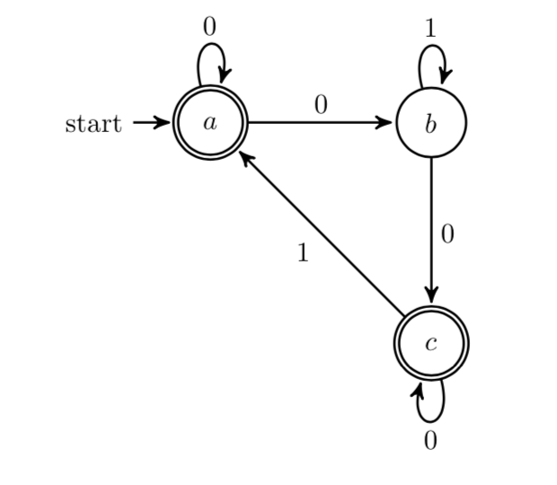

   3. In the second phase, states are ``ripped out" of a GNFA until only two states remain. Using that process, show what happens when state $a$ is ripped out of the GNFA shown below. (You don’t have to complete the process, just do this one step.)

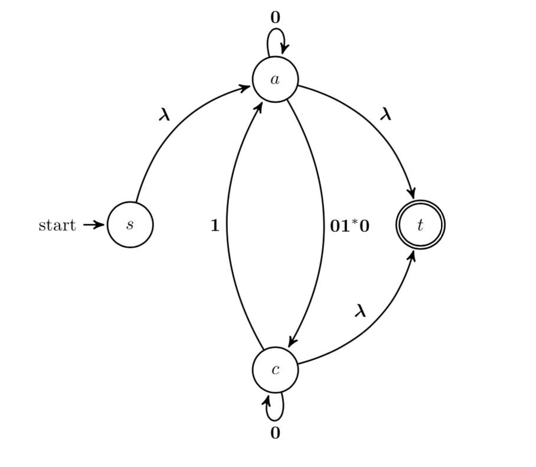